# NOAA Analysis

Zeid El Ameli

5/1/2022

## R Markdown

```r
noaa <- read.csv("~/NOAA.csv")
```

## Subseting Our Data

the original dataframe is too large, we don’t need all the columns in it. so, we limited the data to only a few columns that we’re interested in.

```r
sub_noaa <- noaa[c("BEGIN_DATE_TIME","END_DATE_TIME","EPISODE_ID","EVENT_ID","STATE","STATE_FIPS","CZ_NAME","CZ_TYPE","CZ_FIPS","EVENT_TYPE","SOURCE","BEGIN_LAT","BEGIN_LON","END_LAT","END_LON")]
head(sub_noaa)
```

```
##      BEGIN_DATE_TIME      END_DATE_TIME EPISODE_ID EVENT_ID   STATE STATE_FIPS
## 1 27-MAR-94 11:32:00 27-MAR-94 11:32:00         NA 10314418 ALABAMA          1
## 2 15-MAY-94 19:30:00 15-MAY-94 19:30:00         NA 10314419 ALABAMA          1
## 3 26-JUN-94 22:20:00 26-JUN-94 22:20:00         NA 10314420 ALABAMA          1
## 4 15-MAY-94 13:47:00 15-MAY-94 13:47:00         NA 10314036 ALABAMA          1
## 5 27-MAR-94 15:50:00 27-MAR-94 15:50:00         NA 10314044 ALABAMA          1
## 6 27-MAR-94 15:50:00 27-MAR-94 15:50:00         NA 10314045 ALABAMA          1
##      CZ_NAME CZ_TYPE CZ_FIPS        EVENT_TYPE SOURCE BEGIN_LAT BEGIN_LON
## 1     DEKALB       C      49           Tornado     NA     34.43    -85.98
## 2     DEKALB       C      49 Thunderstorm Wind     NA        NA        NA
## 3     DEKALB       C      49 Thunderstorm Wind     NA        NA        NA
## 4 TALLAPOOSA       C     123              Hail     NA        NA        NA
## 5 TUSCALOOSA       C     125              Hail     NA        NA        NA
## 6 TUSCALOOSA       C     125              Hail     NA        NA        NA
##   END_LAT END_LON
## 1   34.47  -85.78
## 2      NA      NA
## 3      NA      NA
## 4      NA      NA
## 5      NA      NA
## 6      NA      NA
```

## Ordering Our Data

Next step is ordering the data by the beginning year and month.

```r
arranged_noaa <-noaa[order(noaa$BEGIN_YEARMONTH),]
```

## Changing The Case of States and Counties

In our data, State & County names are stored in upper case. We will now change them to title case.

```r
noaa$title_state <-str_to_title(noaa$STATE, locale = "en")
noaa$title_cz <-str_to_title(noaa$CZ_NAME, locale = "en")
```

## Limiting Our Data

Now, we want to only include data from CZ_TYPE of “C”.

```r
filtered <- filter(noaa, CZ_TYPE == "C") %>%
  select(-CZ_TYPE)
```

##Combining Columns

We want to add a “0” in front of our STATE_FIPS & CZ_FIPS columns, then combine the two into 1!

```r
noaa$concat <- str_c("0",noaa$STATE_FIPS,"0",noaa$CZ_FIPS)
```

## Renaming Columns to Lower Case

We noticed that all our column names are in UPPER CASE, we now want to change them to lower case.

```r
noaa <- as_tibble(noaa)
rename_all(noaa, tolower)
```

```
## # A tibble: 15,627 x 54
##    begin_yearmonth begin_day begin_time end_yearmonth end_day end_time
##              <int>     <int>      <int>         <int>   <int>    <int>
##  1          199403        27       1132        199403      27     1132
##  2          199405        15       1930        199405      15     1930
##  3          199406        26       2220        199406      26     2220
##  4          199405        15       1347        199405      15     1347
##  5          199403        27       1550        199403      27     1550
##  6          199403        27       1550        199403      27     1550
##  7          199403        27       1555        199403      27     1555
##  8          199403        27       1602        199403      27     1602
##  9          199411        27       1820        199411      27     1820
## 10          199411        27       2130        199411      27     2130
## # ... with 15,617 more rows, and 48 more variables: episode_id <lgl>,
## #   event_id <int>, state <chr>, state_fips <int>, year <int>,
## #   month_name <chr>, event_type <chr>, cz_type <chr>, cz_fips <int>,
## #   cz_name <chr>, wfo <lgl>, begin_date_time <chr>, cz_timezone <chr>,
## #   end_date_time <chr>, injuries_direct <int>, injuries_indirect <int>,
## #   deaths_direct <int>, deaths_indirect <int>, damage_property <chr>,
## #   damage_crops <chr>, source <lgl>, magnitude <dbl>, ...
```

##Building Dataframes From Base R Code

Base R has some useful datasets, ones of them is a dataset about US states and some valuable info about each. Let’s build a dataframe from that dataset!

```r
state_info <- data.frame(state=state.name, region=state.region, area=state.area)
```

## Merging Dataframes

We now want to merge dataframes from both our own imported dataframe, and the base dataframe in R.

```r
freq_table <- data.frame(table(noaa$STATE))
freq_table1 <- rename(freq_table,c("state"="Var1"))
freq_table1$title_state <- str_to_title(freq_table1$state, locale = "en")
freq_table1 = freq_table1[-c(1)]
merged <- merge(x=freq_table1,y=state_info,by.x="title_state",by.y="state")
head(merged)
```

```
##   title_state Freq    region   area
## 1     Alabama  266     South  51609
## 2     Arizona   67      West 113909
## 3    Arkansas  893     South  53104
## 4  California   22      West 158693
## 5    Colorado  308      West 104247
## 6 Connecticut   45 Northeast   5009
```

## Plotting Our Data

Now, we would like to see a graph that shows us states by area and number of storms hit it in 1994.

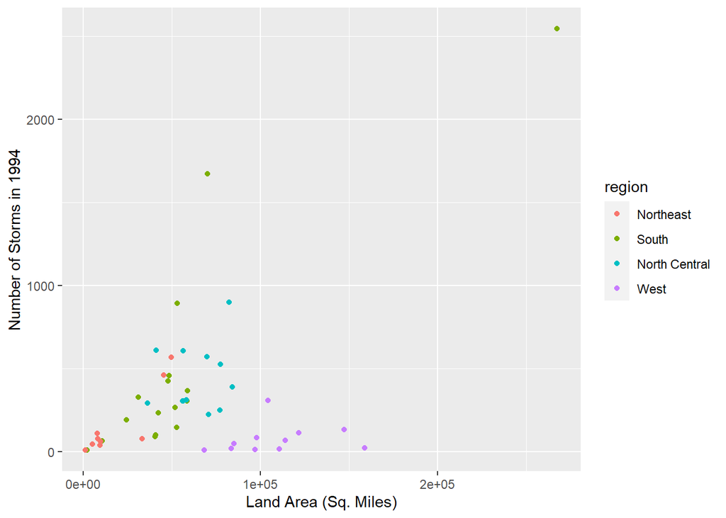

```r
plot <- ggplot(merged, aes(x= area, y=Freq)) +
  geom_point(aes(color = region)) +
  labs(x="Land Area (Sq. Miles)", y="Number of Storms in 1994")
plot
```